# Using DEEP LEARNING WITH KERAS TO PREDICT CUSTOMER CHURN in IBM Watson Telco Dataset

Customer churn refers to the situation when a customer ends their relationship with a company, and it’s a costly problem. Customers are the fuel that powers a business. Loss of customers impacts sales. Further, it’s much more difficult and costly to gain new customers than it is to retain existing customers. As a result, organizations need to focus on reducing customer churn.

The good news is that machine learning can help. For many businesses that offer subscription based services, it’s critical to both predict customer churn and explain what features relate to customer churn. Older techniques such as logistic regression can be less accurate than newer techniques such as deep learning, which is why this report is going to model an ANN in R with the keras package.

The data is from https://www.ibm.com/communities/analytics/watson-analytics-blog/predictive-insights-in-the-telco-customer-churn-data-set/. This data set provides info to predict behavior to retain customers. We can analyze all relevant customer data and develop focused customer retention programs. A telecommunications company is concerned about the number of customers leaving their landline business for cable competitors. They need to understand who is leaving. Imagine that you’re an analyst at this company and you have to find out who is leaving and why. The data set includes information about: - Customers who left within the last month - the column is called Churn - Services that each customer has signed up for - phone, multiple lines, internet, online security, online backup, device protection, tech support, and streaming TV and movies - Customer account information - how long they’ve been a customer, contract, payment method, paperless billing, monthly charges, and total charges - Demographic info about customers - gender, age range, and if they have partners and dependents

1. Install required packages

We use the following libraries in this tutorial:

- keras: Library that ports Keras from Python enabling deep learning in R. Visit the documentation for more information.
- lime: Used to explain the predictions of black box classifiers. Deep Learning falls into this category.
- tidyquant: Loads the tidyverse (dplyr, ggplot2, etc) and has nice visualization functions with theme_tq(). Visit the tidyquant documentation and the tidyverse documentation for more information on the individual packages.
- rsample: New package for generating resamples. Visit the documentation for more information.
- recipes: New package for preprocessing machine learning data sets. Visit the documentation for more information.
- yardstick: Tidy methods for measuring model performance. Visit the GitHub Page for more information.
- corrr: Tidy methods for correlation. Visit the GitHub Page for more information.

```r
pkgs <- c("keras", "lime", "tidyquant", "rsample", "recipes", "yardstick", "corrr")
install.packages(pkgs)
```

```r
# Load libraries
library(keras)
library(lime)
library(tidyquant)
library(rsample)
library(recipes)
library(yardstick)
library(corrr)
```

```r
# Install Keras if you have not installed before
install_keras()
```

[output not shown]

[output not shown]

[output cut: 2113 more lines]

[output not shown]

[output not shown]

[output not shown]

[output cut: 13863 more lines]

[output not shown]

```r
# Import data
setwd("D:/Projects/Data_science/churn analysis")
churn_data_raw <- read_csv("WA_Fn-UseC_-Telco-Customer-Churn.csv")
glimpse(churn_data_raw)
```

```
Observations: 7,043
Variables: 21
$ customerID       <chr> "7590-VHVEG", "5575-GNVDE", "3668-QPYBK", "7...
$ gender           <chr> "Female", "Male", "Male", "Male", "Female", ...
$ SeniorCitizen    <int> 0, 0, 0, 0, 0, 0, 0, 0, 0, 0, 0, 0, 0, 0, 0,...
$ Partner          <chr> "Yes", "No", "No", "No", "No", "No", "No", "...
$ Dependents       <chr> "No", "No", "No", "No", "No", "No", "Yes", "...
$ tenure           <int> 1, 34, 2, 45, 2, 8, 22, 10, 28, 62, 13, 16, ...
$ PhoneService     <chr> "No", "Yes", "Yes", "No", "Yes", "Yes", "Yes...
$ MultipleLines    <chr> "No phone service", "No", "No", "No phone se...
$ InternetService  <chr> "DSL", "DSL", "DSL", "DSL", "Fiber optic", "...
$ OnlineSecurity   <chr> "No", "Yes", "Yes", "Yes", "No", "No", "No",...
$ OnlineBackup     <chr> "Yes", "No", "Yes", "No", "No", "No", "Yes",...
$ DeviceProtection <chr> "No", "Yes", "No", "Yes", "No", "Yes", "No",...
$ TechSupport      <chr> "No", "No", "No", "Yes", "No", "No", "No", "...
$ StreamingTV      <chr> "No", "No", "No", "No", "No", "Yes", "Yes", ...
$ StreamingMovies  <chr> "No", "No", "No", "No", "No", "Yes", "No", "...
$ Contract         <chr> "Month-to-month", "One year", "Month-to-mont...
$ PaperlessBilling <chr> "Yes", "No", "Yes", "No", "Yes", "Yes", "Yes...
$ PaymentMethod    <chr> "Electronic check", "Mailed check", "Mailed ...
$ MonthlyCharges   <dbl> 29.85, 56.95, 53.85, 42.30, 70.70, 99.65, 89...
$ TotalCharges     <dbl> 29.85, 1889.50, 108.15, 1840.75, 151.65, 820...
$ Churn            <chr> "No", "No", "Yes", "No", "Yes", "Yes", "No",...
```

The raw data contains 7043 rows (customers) and 21 columns (features). The “Churn” column is our target.

Use sapply to check the number if missing values in each columns

```r
sapply(churn_data_raw, function(x) sum(is.na(x)))
```

```
      customerID           gender    SeniorCitizen          Partner
               0                0                0                0
      Dependents           tenure     PhoneService    MultipleLines
               0                0                0                0
 InternetService   OnlineSecurity     OnlineBackup DeviceProtection
               0                0                0                0
     TechSupport      StreamingTV  StreamingMovies         Contract
               0                0                0                0
PaperlessBilling    PaymentMethod   MonthlyCharges     TotalCharges
               0                0                0               11
           Churn
               0
```

Data columns and rows pruning: -The “customerID” column is a unique identifier for each observation that isn’t needed for modeling. We can de-select this column. -11 missing values in “TotalCharges” columns needed to be removed. perform the cleaning operation with one tidyverse pipe (%>%) chain.

```r
# Remove unnecessary data
churn_data_tbl <- churn_data_raw %>%
    select(-customerID) %>%
    drop_na() %>%
    select(Churn, everything())
glimpse(churn_data_tbl)
```

```
Observations: 7,032
Variables: 20
$ Churn            <chr> "No", "No", "Yes", "No", "Yes", "Yes", "No",...
$ gender           <chr> "Female", "Male", "Male", "Male", "Female", ...
$ SeniorCitizen    <int> 0, 0, 0, 0, 0, 0, 0, 0, 0, 0, 0, 0, 0, 0, 0,...
$ Partner          <chr> "Yes", "No", "No", "No", "No", "No", "No", "...
$ Dependents       <chr> "No", "No", "No", "No", "No", "No", "Yes", "...
$ tenure           <int> 1, 34, 2, 45, 2, 8, 22, 10, 28, 62, 13, 16, ...
$ PhoneService     <chr> "No", "Yes", "Yes", "No", "Yes", "Yes", "Yes...
$ MultipleLines    <chr> "No phone service", "No", "No", "No phone se...
$ InternetService  <chr> "DSL", "DSL", "DSL", "DSL", "Fiber optic", "...
$ OnlineSecurity   <chr> "No", "Yes", "Yes", "Yes", "No", "No", "No",...
$ OnlineBackup     <chr> "Yes", "No", "Yes", "No", "No", "No", "Yes",...
$ DeviceProtection <chr> "No", "Yes", "No", "Yes", "No", "Yes", "No",...
$ TechSupport      <chr> "No", "No", "No", "Yes", "No", "No", "No", "...
$ StreamingTV      <chr> "No", "No", "No", "No", "No", "Yes", "Yes", ...
$ StreamingMovies  <chr> "No", "No", "No", "No", "No", "Yes", "No", "...
$ Contract         <chr> "Month-to-month", "One year", "Month-to-mont...
$ PaperlessBilling <chr> "Yes", "No", "Yes", "No", "Yes", "Yes", "Yes...
$ PaymentMethod    <chr> "Electronic check", "Mailed check", "Mailed ...
$ MonthlyCharges   <dbl> 29.85, 56.95, 53.85, 42.30, 70.70, 99.65, 89...
$ TotalCharges     <dbl> 29.85, 1889.50, 108.15, 1840.75, 151.65, 820...
```

Bar plots of categorical variables

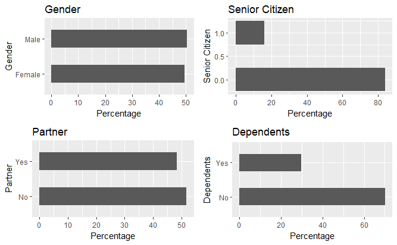

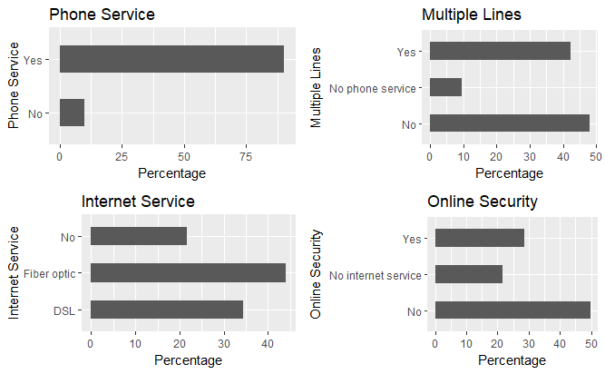

```r
grid.arrange(p5, p6, p7, p8, ncol=2)
```

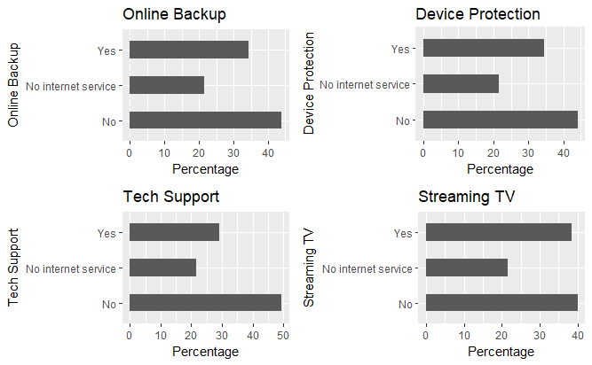

```r
grid.arrange(p9, p10, p11, p12, ncol=2)
```

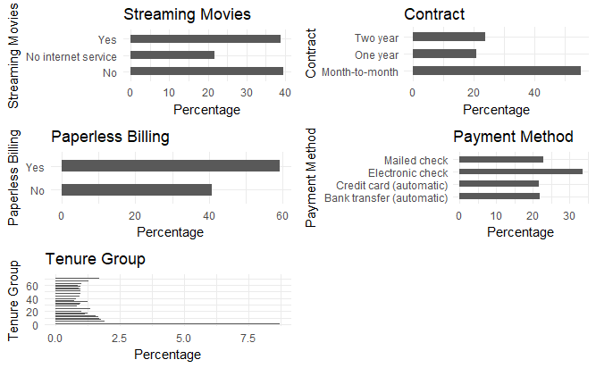

```r
grid.arrange(p13, p14, p15, p16, p17, ncol=2)
```

All of the categorical variables seem to have a reasonably broad distribution, therefore, all of them will be kept for the further analysis.

SPLIT INTO TRAIN/TEST SETS

```r
# Split test/training sets
set.seed(100)
train_test_split <- initial_split(churn_data_tbl, prop = 0.8)
train_test_split
```

```
<5626/1406/7032>
```

# retrieve training and testing sets using training() and testing() functions.

```r
# Retrieve train and test sets
train_tbl <- training(train_test_split)
test_tbl  <- testing(train_test_split)
```

Based on the data, feature transformation are needed: 1. DISCRETIZE THE “TENURE” FEATURE into groups and split into six cohorts that divide up the user base by tenure in roughly one year (12 month) increments 2. TRANSFORM THE “TOTALCHARGES” FEATURE: do a log transform and make it more normally distrubuted.

```r
# Determine if log transformation improves correlation
# between TotalCharges and Churn
train_tbl %>%
    select(Churn, TotalCharges) %>%
    mutate(
        Churn = Churn %>% as.factor() %>% as.numeric(),
        LogTotalCharges = log(TotalCharges)
        ) %>%
    correlate() %>%
    focus(Churn) %>%
    fashion()
```

| rowname | Churn |
| --- | --- |
| TotalCharges | -.20 |
| LogTotalCharges | -.25 |

Log transform of total charges increase correlations with churn.

3. ONE-HOT ENCODING for Gender, Contract, Internet Service, Multiple Lines, and Payment Method.
4. FEATURE SCALING: centered and scaled data for ANN, and other ML algorithms.

PREPROCESSING WITH RECIPES R package

```r
# Create recipe
rec_obj <- recipe(Churn ~ ., data = train_tbl) %>%
    step_discretize(tenure, options = list(cuts = 6)) %>%
    step_log(TotalCharges) %>%
    step_dummy(all_nominal(), -all_outcomes()) %>%
    step_center(all_predictors(), -all_outcomes()) %>%
    step_scale(all_predictors(), -all_outcomes()) %>%
    prep(data = train_tbl)
```

```r
# Print the recipe object
rec_obj
```

```
Data Recipe

Inputs:

      role #variables
   outcome          1
 predictor         19

Training data contained 5626 data points and no missing data.

Steps:

Dummy variables from tenure [trained]
Log transformation on TotalCharges [trained]
Dummy variables from gender, Partner, Dependents, tenure, ... [trained]
Centering for SeniorCitizen, ... [trained]
Scaling for SeniorCitizen, ... [trained]
```

Processes the data following recipe steps uisng bake()

```r
# Predictors
x_train_tbl <- bake(rec_obj, newdata = train_tbl)
x_test_tbl  <- bake(rec_obj, newdata = test_tbl)
glimpse(x_train_tbl)
```

```
Observations: 5,626
Variables: 36
$ Churn                                 <fctr> No, No, No, Yes, Yes,...
$ SeniorCitizen                         <dbl> -0.4351959, -0.4351959...
$ MonthlyCharges                        <dbl> -1.157597168, -0.26013...
$ TotalCharges                          <dbl> -2.275819130, 0.389259...
$ gender_Male                           <dbl> -1.0016900, 0.9981354,...
$ Partner_Yes                           <dbl> 1.0262054, -0.9742906,...
$ Dependents_Yes                        <dbl> -0.6507747, -0.6507747...
$ tenure_bin1                           <dbl> 2.1677790, -0.4612196,...
$ tenure_bin2                           <dbl> -0.4389453, -0.4389453...
$ tenure_bin3                           <dbl> -0.4481273, -0.4481273...
$ tenure_bin4                           <dbl> -0.4509837, 2.2169809,...
$ tenure_bin5                           <dbl> -0.4498419, -0.4498419...
$ tenure_bin6                           <dbl> -0.4337508, -0.4337508...
```

[output cut: 23 more lines]

```r
glimpse(x_test_tbl)
```

```
Observations: 1,406
Variables: 36
$ Churn                                 <fctr> Yes, Yes, No, No, No,...
$ SeniorCitizen                         <dbl> -0.4351959, -0.4351959...
$ MonthlyCharges                        <dbl> -0.36279525, 1.3245029...
$ TotalCharges                          <dbl> -1.44868709, 0.6960816...
$ gender_Male                           <dbl> 0.9981354, -1.0016900,...
$ Partner_Yes                           <dbl> -0.9742906, 1.0262054,...
$ Dependents_Yes                        <dbl> -0.6507747, -0.6507747...
$ tenure_bin1                           <dbl> 2.1677790, -0.4612196,...
$ tenure_bin2                           <dbl> -0.4389453, -0.4389453...
$ tenure_bin3                           <dbl> -0.4481273, 2.2311121,...
$ tenure_bin4                           <dbl> -0.4509837, -0.4509837...
$ tenure_bin5                           <dbl> -0.4498419, -0.4498419...
$ tenure_bin6                           <dbl> -0.4337508, -0.4337508...
```

[output cut: 23 more lines]

```r
# Response variables for training and testing sets
y_train_vec <- ifelse(pull(train_tbl, Churn) == "Yes", 1, 0)
y_test_vec  <- ifelse(pull(test_tbl, Churn) == "Yes", 1, 0)
```

```r
# Remove target variables Churn from training/test data.
x_train_tbl$Churn = NULL
x_test_tbl$Churn = NULL
```

BUILDING A DEEP LEARNING MODEL USING Keras MLP

```r
# Building our Artificial Neural Network
model_keras <- keras_model_sequential() #Initialize a sequential model
```

[output not shown]

```r
model_keras %>%
    # First hidden layer
    layer_dense(
        units              = 16,
        kernel_initializer = "uniform",
        activation         = "relu",
        input_shape        = ncol(x_train_tbl)) %>%
    # Dropout to prevent overfitting
    layer_dropout(rate = 0.1) %>%
    # Second hidden layer
    layer_dense(
        units              = 16,
        kernel_initializer = "uniform",
        activation         = "relu") %>%
    # Dropout to prevent overfitting
    layer_dropout(rate = 0.1) %>%
    # Output layer
    layer_dense(
        units              = 1,
        kernel_initializer = "uniform",
        activation         = "sigmoid") %>%
    # Compile ANN
    compile(
        optimizer = 'adam',
        loss      = 'binary_crossentropy',
        metrics   = c('accuracy')
    )
model_keras
```

```
Model
_________________________________________________________________________
Layer (type)                    Output Shape                  Param #
=========================================================================
dense_1 (Dense)                 (None, 16)                    576
_________________________________________________________________________
dropout_1 (Dropout)             (None, 16)                    0
_________________________________________________________________________
dense_2 (Dense)                 (None, 16)                    272
_________________________________________________________________________
dropout_2 (Dropout)             (None, 16)                    0
_________________________________________________________________________
dense_3 (Dense)                 (None, 1)                     17
=========================================================================
Total params: 865
Trainable params: 865
Non-trainable params: 0
_________________________________________________________________________
```

```r
# Fit the keras model to the training data
fit_keras <- fit(
    object           = model_keras,
    x                = as.matrix(x_train_tbl),
    y                = y_train_vec,
    batch_size       = 50,
    epochs           = 35,
    validation_split = 0.30
    )
```

```
Train on 3938 samples, validate on 1688 samples
```

```r
# Print the final model
fit_keras
```

```
Trained on 3,938 samples, validated on 1,688 samples (batch_size=50, epochs=35)
Final epoch (plot to see history):
val_loss: 0.426
 val_acc: 0.8069
    loss: 0.3972
     acc: 0.8126
```

visualize the Keras training history using the plot() function

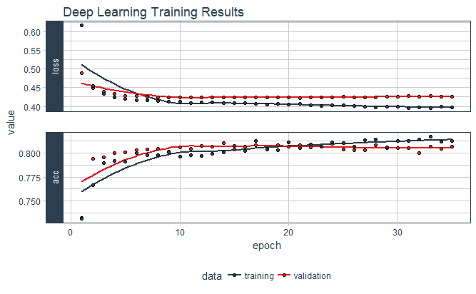

```r
# Plot the training/validation history of our Keras model
plot(fit_keras) +
    theme_tq() +
    scale_color_tq() +
    scale_fill_tq() +
    labs(title = "Deep Learning Training Results")
```

MAKING PREDICTIONS

```r
# Predicted Class
yhat_keras_class_vec <- predict_classes(object = model_keras, x = as.matrix(x_test_tbl)) %>%
    as.vector()
# Predicted Class Probability
yhat_keras_prob_vec  <- predict_proba(object = model_keras, x = as.matrix(x_test_tbl)) %>%
    as.vector()
```

INSPECT PERFORMANCE WITH YARDSTICK

```r
# Format test data and predictions for yardstick metrics
estimates_keras_tbl <- tibble(
    truth      = as.factor(y_test_vec) %>% fct_recode(yes = "1", no = "0"),
    estimate   = as.factor(yhat_keras_class_vec) %>% fct_recode(yes = "1", no = "0"),
    class_prob = yhat_keras_prob_vec
)
estimates_keras_tbl
```

| truth | estimate | class_prob |
| --- | --- | --- |
| yes | no | 0.248989001 |
| yes | yes | 0.623343527 |
| no | no | 0.004752867 |
| no | no | 0.008489167 |
| no | no | 0.030721333 |
| no | no | 0.118988708 |
| no | yes | 0.782555163 |
| no | no | 0.472405434 |
| no | no | 0.010166749 |
| no | no | 0.004020641 |

[output cut: 990 more lines]

```r
options(yardstick.event_first = FALSE)
```

Check performance using confusion matrix, accuracy, AUC, precision, recall and F1 score.

```r
# Confusion Table
estimates_keras_tbl %>% conf_mat(truth, estimate)
```

```
          Truth
Prediction  no yes
       no  942 161
       yes 107 196
```

```r
# Accuracy
estimates_keras_tbl %>% metrics(truth, estimate)
```

| accuracy |
| --- |
| 0.8093883 |

```r
# AUC
estimates_keras_tbl %>% roc_auc(truth, class_prob)
```

```
[1] 0.8516688
```

```r
# Precision
tibble(
    precision = estimates_keras_tbl %>% precision(truth, estimate),
    recall    = estimates_keras_tbl %>% recall(truth, estimate)
)
```

| precision | recall |
| --- | --- |
| 0.6468647 | 0.5490196 |

```r
# F1-Statistic
estimates_keras_tbl %>% f_meas(truth, estimate, beta = 1)
```

```
[1] 0.5939394
```